# Stat 579 - Homework #6

10/11/2018

## Another look at the Behavioral Risk Factor Surveillance System

We are, again, using the data from the Behavioral Risk Factor Surveillance System (BRFSS). Just as a reminder, the BRFSS surveys six individual-level behavioral health risk factors associated with the leading causes of premature mortality and morbidity among adults: 1) cigarette smoking, 2) alcohol use, 3) physical activity, 4) diet, 5) hypertension, and 6) safety belt use.

A subset of the data concentrating on Iowa with records for 2012 is given at http://www.hofroe.net/data/iowa-brfss-2012.csv

The following code reads the data into your R session:

```r
iowa <- read.csv("http://www.hofroe.net/data/iowa-brfss-2012.csv")
library(tidyverse)
```

For each of the questions, show the code necessary to retrieve the answer. Make sure to also write the answer to the question in a sentence.

2. Load the dataset into your session and store it in the object `iowa`.
3. Check the codebook for an explanation of the variable `DRNKDRI2`. Do a frequency breakdown of the variable `DRNKDRI2` (visually or numerically). Comment.

```r
library(dplyr)
iowa%>%
  group_by(DRNKDRI2)%>%
  summarise(count=n())
```

```
## # A tibble: 15 x 2
##    DRNKDRI2 count
##       <int> <int>
##  1        1    99
##  2        2    46
##  3        3     8
##  4        4     6
##  5        5     5
##  6        6     1
##  7        8     1
##  8       10     2
##  9       12     1
## 10       15     1
## 11       20     1
## 12       77     3
## 13       88  3537
## 14       99    13
## 15       NA  3442
```

```r
# or
library(data.table)
dt=data.table(iowa)
freq=dt[, .N, by=DRNKDRI2]
freq
```

```
##     DRNKDRI2    N
##  1:       88 3537
##  2:       NA 3442
##  3:        3    8
##  4:        1   99
##  5:        2   46
##  6:       99   13
##  7:       77    3
##  8:        6    1
##  9:       10    2
## 10:        4    6
## 11:        5    5
## 12:       20    1
## 13:       15    1
## 14:       12    1
## 15:        8    1
```

Introduce a variable `drinkdrive` into the `iowa` data set that encodes 88 as 0, and 77 and 99 as `NA`.  
Hint: a combination of `mutate` and `ifelse` might be helpful.

```r
a=iowa %>%
  mutate(drinkdrive=ifelse(DRNKDRI2==88, 0, ifelse(DRNKDRI2==77|DRNKDRI2==99, NA, DRNKDRI2)))

# or

iowa$drinkdrive=ifelse(iowa$DRNKDRI2==88, 0, ifelse(iowa$DRNKDRI2==77|iowa$DRNKDRI2==99, NA, iowa$DRNKDRI2))
```

Find the following summaries:

```
a. What is the average number of times respondents admitted to driving under the influence in the past 30 days?
```

```r
d <- mean(iowa$drinkdrive, na.rm = T)
d
```

```
## [1] 0.09304207
```

```
b. On how many reports is this average based (exclude missing values)?
```

```r
f <- iowa %>%
  group_by(drinkdrive) %>%
  summarise(count=n(), na.rm=T)
f
```

```
## # A tibble: 13 x 3
##    drinkdrive count na.rm
##         <dbl> <int> <lgl>
##  1          0  3537 TRUE
##  2          1    99 TRUE
##  3          2    46 TRUE
##  4          3     8 TRUE
##  5          4     6 TRUE
##  6          5     5 TRUE
##  7          6     1 TRUE
##  8          8     1 TRUE
##  9         10     2 TRUE
## 10         12     1 TRUE
## 11         15     1 TRUE
## 12         20     1 TRUE
## 13         NA  3458 TRUE
```

```r
sum(f$count)-3458
```

```
## [1] 3708
```

```
c. Is there a difference in this average between the genders? Is that difference significant?
```

```r
iowa%>%
  group_by(SEX)%>%
  summarise(mu=mean(drinkdrive, na.rm = T))
```

```
## # A tibble: 2 x 2
##     SEX     mu
##   <int>  <dbl>
## 1     1 0.162
## 2     2 0.0295
```

4. Current smoking status is imputed in the variable `X_SMOKER3` (corresponds to variable `_SMOKER3` in the codebook). Make `X_SMOKER3` a factor. Relabel levels 1, 2, 3, 4 to `Current Smoker`, `Current Smoker`, `Former Smoker` and `Never Smoked` (yes, `Current Smoker` is repeated on purpose) and level 9 to NA.

```r
iowa$X_SMOKER33=factor(iowa$X_SMOKER3)
levels(iowa$X_SMOKER33)=c("Current Smoker", "Current Smoker", "Former Smoker", "Never Smoked", "NA")
```

```
b. Describe the relationship between smoking status and age (use `X_AGE_G` - read up on `_AGE_G` in the codebook) based on an appropriate visualization.
```

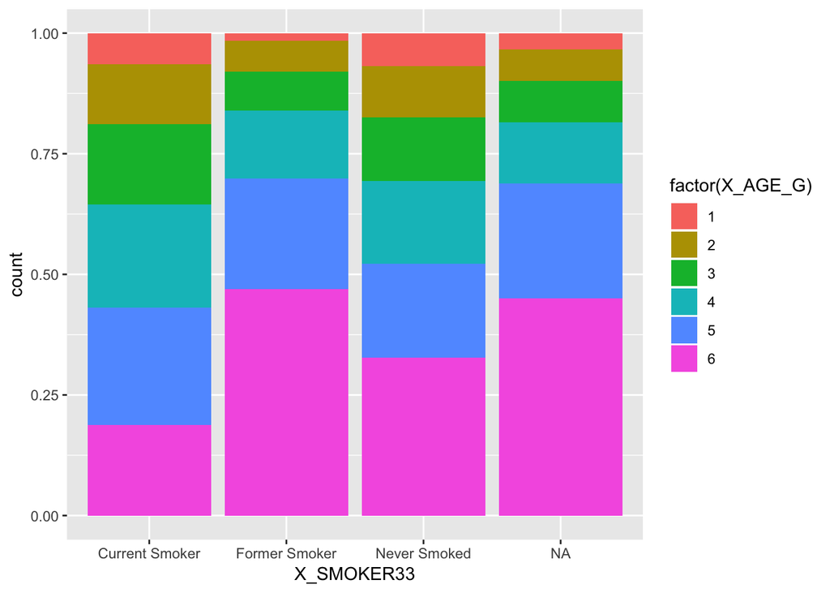

```r
library(ggplot2)
ggplot(iowa, aes(X_SMOKER33))+
  geom_bar(aes(fill=factor(X_AGE_G)), position="fill")
```

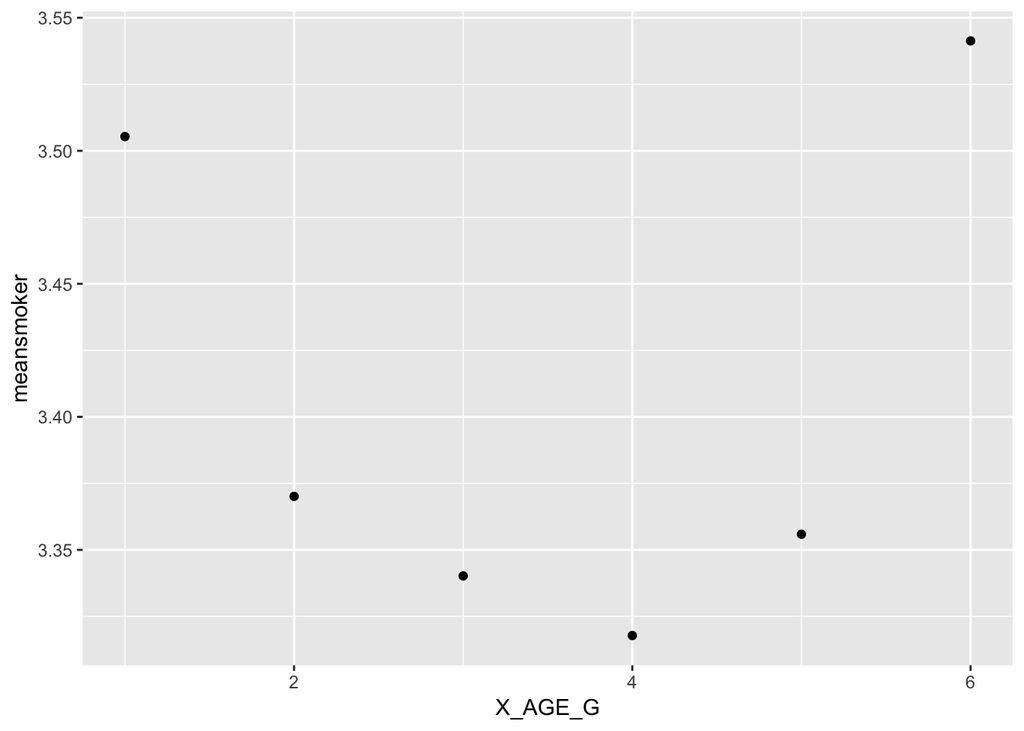

```r
# or
iowa%>%
  group_by(X_AGE_G)%>%
  summarise(meansmoker=mean(X_SMOKER3))%>%
  ggplot(aes(X_AGE_G, meansmoker))+
  geom_point()
```

5. What percentage of the population has never smoked? Calculate this percentage by age groups (`X_AGE_G`) and gender (`SEX`).

```r
iowa %>%
  group_by(SEX, X_AGE_G) %>%
  summarise(totalsmoke3=sum(X_SMOKER33!="NA"), precentage=sum(X_SMOKER33 == "Never Smoked", na.rm = T)/totalsmoke3)
```

```
## # A tibble: 12 x 4
## # Groups:   SEX [?]
##      SEX X_AGE_G totalsmoke3 precentage
##    <int>   <int>       <int>      <dbl>
##  1     1       1         187      0.701
##  2     1       2         310      0.555
##  3     1       3         372      0.567
##  4     1       4         494      0.516
##  5     1       5         654      0.448
##  6     1       6         854      0.333
##  7     2       1         182      0.758
##  8     2       2         369      0.664
##  9     2       3         488      0.637
## 10     2       4         689      0.608
## 11     2       5         833      0.569
## 12     2       6        1583      0.637
```

```
b. Report also on the number of respondents these percentages are based on.
```

```r
iowa%>%
   filter(X_SMOKER33!="NA")%>%
  group_by(SEX, X_AGE_G)%>%
  summarise(count=n())
```

```
## # A tibble: 12 x 3
## # Groups:   SEX [?]
##      SEX X_AGE_G count
##    <int>   <int> <int>
##  1     1       1   187
##  2     1       2   310
##  3     1       3   372
##  4     1       4   494
##  5     1       5   654
##  6     1       6   854
##  7     2       1   182
##  8     2       2   369
##  9     2       3   488
## 10     2       4   689
## 11     2       5   833
## 12     2       6  1583
```

6. Self assessed health status is used as an indicator in a lot of health andn insurance models. Read up on variable `POORHLTH` in the codebook and recode levels to ‘meaningful’ numbers (similar to question 3).

```r
iowa$POORHLTHnew=ifelse(iowa$POORHLTH==88, 0, ifelse(iowa$POORHLTH==77|iowa$POORHLTH==99|iowa$POORHLTH=="", NA, iowa$POORHLTH))
```

```
b. What is the relationship between age and the number of  poor health days? Is this relationship    different for men and women? Show plot(s) and describe.
```

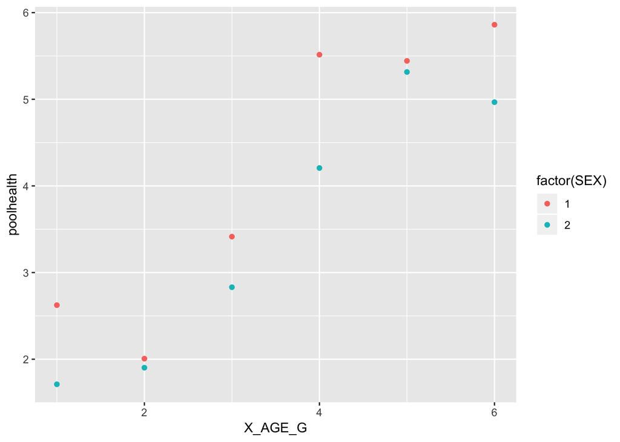

```r
iowa %>%
  group_by(X_AGE_G, SEX)%>%
  summarise(poolhealth=mean(POORHLTHnew, na.rm = T) )%>%
  ggplot(aes(X_AGE_G, poolhealth )) + geom_point(aes(colour=factor(SEX)))
```